# Practical Machine Learning Course Project

Jordan Rinder

July 24, 2015

## Data Information

In this project, the goal will be to use data from accelerometers on the belt, forearm, arm, and dumbell of 6 participants. They were asked to perform barbell lifts correctly and incorrectly in 5 different ways. More information is available from the website here: http://groupware.les.inf.puc-rio.br/har (see the section on the Weight Lifting Exercise Dataset).

- **Data**
  - The Training Data can be found [here](https://d396qusza40orc.cloudfront.net/predmachlearn/pml-training.csv)
  - The Testing Data can be found [here](https://d396qusza40orc.cloudfront.net/predmachlearn/pml-testing.csv)

## Loading Data

In this section we will load the data into our R session along with any packages that we will be using

```r
library(caret)
library(randomForest)
library(gbm)
```

```r
library(ggplot2)

training <- read.csv("pml-training.csv", na.strings=c("NA","#DIV/0!",""))
testing <- read.csv("pml-testing.csv", na.strings=c("NA","#DIV/0!",""))
```

## Cleaning the Data

Now we shall clean the data by taking out the columns that are predominantly NA’s and partitioning the training dataset so that there is a new training data set along with a new testing data set. This allows us to leave the *original* testing set alone.

- We partition the *original* training set so that the new training set consists of 70% of the original, while the new testing set consists of 30% of the original training set
- We also omit the first 7 columns as each contains information that is not useful for this machine learning task

```r
training <- training[,colSums(is.na(training)) == 0]
testing <- testing[,colSums(is.na(testing)) == 0]
training <- training[, -c(1:7)]
testing <- testing[, -c(1:7)]
dim(training); dim(testing)
```

```
## [1] 19622    53
```

```
## [1] 20 53
```

```r
subData <- createDataPartition(y = training$classe, p = 0.7, list = F)
subTraining <- training[subData, ]
subTesting <- training[-subData, ]
dim(subTraining); dim(subTesting)
```

```
## [1] 13737    53
```

```
## [1] 5885   53
```

### Cross Validation Method

Our Cross Validation Method is simply splitting the original training set into a new training and new testining set. This new testing data set can be thought of as a cross validation data set

### Plot of the *Classe* variable

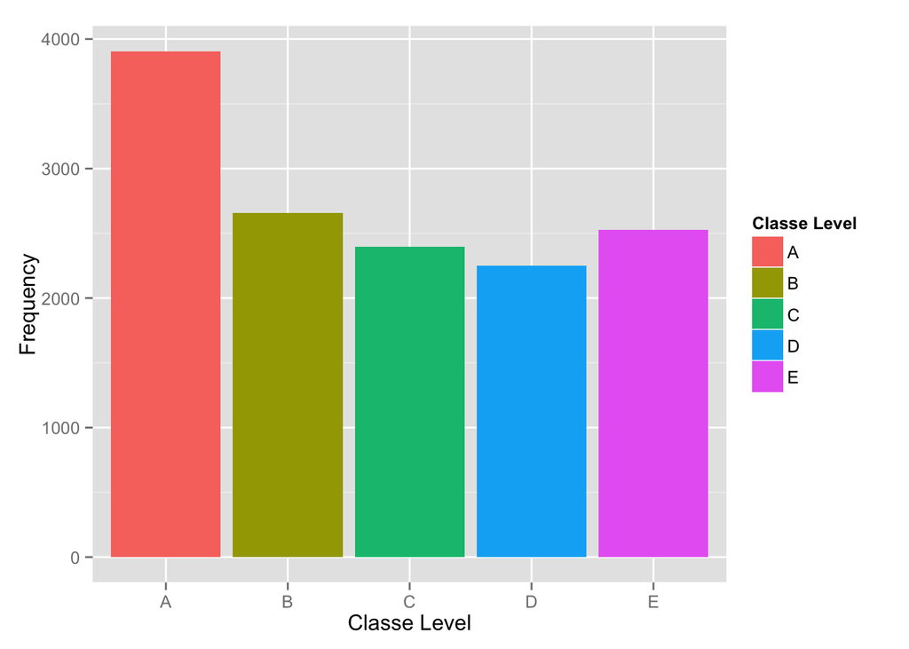

```r
qplot(factor(classe), data = subTraining, geom = "bar", fill = factor(classe)) +
    ylab("Frequency") + xlab("Classe Level") + scale_fill_discrete(name = "Classe Level")
```

## Model Selection

1. Before we do anything we must the the seed so that our results are reproducable
2. Our first model is the Generalized Boosted Regression Model

```r
set.seed(1234)

modelFit2 <- train(classe ~., data = subTraining, method = "gbm", verbose = F)
pred2 <- predict(modelFit2, subTesting)
gbm <- confusionMatrix(pred2, subTesting$classe)
gbm
```

```
## Confusion Matrix and Statistics
##
##           Reference
## Prediction    A    B    C    D    E
##          A 1643   38    0    0    2
##          B   21 1068   30    6   10
##          C    7   28  980   20    9
##          D    2    2   15  924   19
##          E    1    3    1   14 1042
##
## Overall Statistics
##
##                Accuracy : 0.9613
##                  95% CI : (0.956, 0.966)
##     No Information Rate : 0.2845
##     P-Value [Acc > NIR] : < 2.2e-16
##
##                   Kappa : 0.951
##  Mcnemar's Test P-Value : 0.001844
##
## Statistics by Class:
##
##                      Class: A Class: B Class: C Class: D Class: E
## Sensitivity            0.9815   0.9377   0.9552   0.9585   0.9630
## Specificity            0.9905   0.9859   0.9868   0.9923   0.9960
## Pos Pred Value         0.9762   0.9410   0.9387   0.9605   0.9821
## Neg Pred Value         0.9926   0.9851   0.9905   0.9919   0.9917
## Prevalence             0.2845   0.1935   0.1743   0.1638   0.1839
## Detection Rate         0.2792   0.1815   0.1665   0.1570   0.1771
## Detection Prevalence   0.2860   0.1929   0.1774   0.1635   0.1803
## Balanced Accuracy      0.9860   0.9618   0.9710   0.9754   0.9795
```

3. Our second model is generated from the Random Forest package

```r
modS <- randomForest(classe ~. , data = subTraining, method = "class")
pred3 <- predict(modS, subTesting)
rf <- confusionMatrix(pred3, subTesting$classe)
rf
```

```
## Confusion Matrix and Statistics
##
##           Reference
## Prediction    A    B    C    D    E
##          A 1673    6    0    0    0
##          B    1 1129    5    0    0
##          C    0    4 1021    4    3
##          D    0    0    0  960    1
##          E    0    0    0    0 1078
##
## Overall Statistics
##
##                Accuracy : 0.9959
##                  95% CI : (0.9939, 0.9974)
##     No Information Rate : 0.2845
##     P-Value [Acc > NIR] : < 2.2e-16
##
##                   Kappa : 0.9948
##  Mcnemar's Test P-Value : NA
##
## Statistics by Class:
##
##                      Class: A Class: B Class: C Class: D Class: E
## Sensitivity            0.9994   0.9912   0.9951   0.9959   0.9963
## Specificity            0.9986   0.9987   0.9977   0.9998   1.0000
## Pos Pred Value         0.9964   0.9947   0.9893   0.9990   1.0000
## Neg Pred Value         0.9998   0.9979   0.9990   0.9992   0.9992
## Prevalence             0.2845   0.1935   0.1743   0.1638   0.1839
## Detection Rate         0.2843   0.1918   0.1735   0.1631   0.1832
## Detection Prevalence   0.2853   0.1929   0.1754   0.1633   0.1832
## Balanced Accuracy      0.9990   0.9950   0.9964   0.9978   0.9982
```

4. The final step in our model selection is to analyze the models

## Picking A Model / Out of Sample Error

- We can see that the random forest model performs slightly better than the generalized boosted regression model, so we will choose it for our final model
- We can also see that the out of sample error for random forests is lower than the out of sample error for the generalized boosted regression model

```r
accuracy <- data.frame(gbm$overall[1], rf$overall[1])
colnames(accuracy) <- c("GBM Overall", "RF Overall")
accuracy
```

```
##          GBM Overall RF Overall
## Accuracy   0.9612574  0.9959218
```

```r
#Out of Sample Error
osError <- 1 - accuracy
rownames(osError) <- "Out of Sample Error"
osError
```

```
##                     GBM Overall  RF Overall
## Out of Sample Error  0.03874257 0.004078165
```

## Building Our Final Model

```r
predTest <- predict(modS, testing)
predTest
```

```
##  1  2  3  4  5  6  7  8  9 10 11 12 13 14 15 16 17 18 19 20
##  B  A  B  A  A  E  D  B  A  A  B  C  B  A  E  E  A  B  B  B
## Levels: A B C D E
```